# Data Project Foundations

Aaron Chien

6/16/2022

## Introduction

Hello, in this report created by Aaron Chien, finance chair of 2021-2022, you will find a summary of financial data collected from the venmo account over the course of the year. You will also find reccomendations on which fundraisers worked the best and which ones the new admin should be more cautious of.

To start off, I created a new table based off the venmo data and had to fix the descriptions to better represent the data. For example, in the category of “team dues”, this includes all the dues collected from the teams as well as reimbursements for their stipend, photoshoots, and banquet. Each category is like this. The “reimbursement” category are the times where finance team paid someone back money for a certain reason that doesn’t fit for the other category. Everything that deals with merch is separated into their own category. Speaking of merch, merch that deals with shirts and gear have Sparktrendz payments accounted for already and the “Sparktrendz Payment” category was a payment to Sparktrendz, but I couldn’t find which shirt it belonged to. I suspect that it was for the beginning year clothes and merch but I have yet to find an answer.

This is an example of what the table data shows and what this report will be working with.

**Click for Table**

| From | To | Description | Category | Amount |
| --- | --- | --- | --- | --- |
| Foundations Choreography | Leeba Farooqi | Reimbursement | Payments | -71.16 |
| Carl King | Foundations Choreography | Krispy Kreme Fundraiser | Food Fundraiser | 3.00 |
| Rachel Burnett | Foundations Choreography | Krispy Kreme Fundraiser | Food Fundraiser | 1.00 |
| Aaron Chien | Foundations Choreography | Krispy Kreme Fundraiser | Food Fundraiser | 1.00 |
| Aaron Chien | Foundations Choreography | Krispy Kreme Fundraiser | Food Fundraiser | 1.00 |
| Ryan Agcaoili | Foundations Choreography | Krispy Kreme Fundraiser | Food Fundraiser | 3.00 |

## Basic Summary of Data

This table gives you the basic summary for each description, note the max, min, sum, and mean. The mean overall gives us the idea if we received a positive or negative increase in finance while the sum gives us the total amount of money earned from each description. The quantiles can also help in estimating profits as we use the first quantile to show that 25% of the data falls here or below and the third quantile shows that 75% of the data falls here or below. This can be used to gauge revenue or losses.

Each description is obvious while some is not. Here is a summary:

1. 85 Degrees Fundraiser is the fundraiser from 85 degrees bruinwalk
2. Banquet Fees are all the fees from banquet including catering, decorations, lship gifts, and printing.
3. CAMP FC GEAR includes all the payments for the CAMP FC GEAR and the payment to Sparktrendz for the CAMP FC GEAR.
4. Foundations Shirt Merch includes all sales from selling shirt merch and the payment to Sparktrendz for the Foundations shirt merch.
5. Foundations Sticker Merch includes all sales from selling stickers.
6. Foundations Tote Merch includes all sales from selling tote bags.
7. Krispy Kreme Fundraiser includes the fundraiser from selling Krispy Kreme doughnuts on bruinwalk.
8. LSHIP Dare Square includes the fundraiser of dare square from fall quarter.
9. LSHIP Jackets includes all the fees collected for the lship jacket and the payment for the lship jackets.
10. Pie Fundraiser includes all the fundraising from the pies for teams as well as the costs and reimbursements for them.
11. Reimbursement includes all reimbursements that does not fit into any description, mainly reimbursements from auditions, pre-auds, and showcase as well as the payment for the choregraphers from Wintensive.
12. Rose Fundraiser includes all the fundraising from selling roses.
13. Sparktrendz Payment includes all the payment towards Sparktrendz that does not fit into the other descriptions.
14. Anything that includes `dues` except for `Retreat Dues` includes all the fees collected from the teams, photoshoot reimbursements, the `$30` stipend for each team, and team gear.
15. Retreat Dues includes dues collected from lship for retreat as well as any reimbursement from retreat.
16. Teaspoon Fundraiser includes all the fundraising from teaspoon as well as reimbursements for it.
17. Valentines Gram Fundraiser includes all the fundraisig from Valentines Gram as well as the material payments for it.
18. Wintensive Merch includes all the sales from wintensive as well as the payment towards Sparktrendz for the gear.
19. Wintensive Choregrapher includes all the payments made to the wintensive choregraphers.

**Click for Table**

|  | 4G Dues | 85 Degrees Fundraiser | Banquet Fees | BOFA Dues | CAMP FC GEAR | Dale Dues | DDR Dues | DMV Dues | Double Take Dues | Down Bad Dues | Foundations Shirts Merch | Foundations Sticker Merch | Foundations Tote Merch | Krispy Kreme Fundraiser | LSHIP Dare Square | LSHIP Jackets | OOP Dues | Pie Fundraiser | Reimbursement | Retreat Dues | Rose Fundraiser | Sparktrendz Payment | Teaspoon Fundraiser | Valentines Gram Fundraiser | Wintensive Choregrapher | Wintensive Merch | YUH Dues |
| --- | --- | --- | --- | --- | --- | --- | --- | --- | --- | --- | --- | --- | --- | --- | --- | --- | --- | --- | --- | --- | --- | --- | --- | --- | --- | --- | --- |
| Min. | -30 | -229.94 | -367.92 | -12.0 | -825.00 | -15.54 | -30.0 | 30 | -300.00 | -940.50 | -1295.00 | 1.00 | 15.00 | 1.00 | 3.00 | -408.62 | 840 | -40.00 | -320.00 | -872.77 | -688.09 | -3062.5 | -6.45 | -89.09 | -306.0 | -20.00 | -24.96 |
| 1st Qu. | 225 | 3.00 | -69.02 | 193.5 | 25.00 | -12.27 | 7.0 | 195 | -107.84 | -505.38 | 20.00 | 1.50 | 15.00 | 1.00 | 6.50 | 35.00 | 840 | 2.00 | -74.38 | -12.50 | 4.00 | -3062.5 | 5.75 | 2.00 | -304.5 | 20.00 | -9.11 |
| Median | 480 | 4.00 | -21.90 | 399.0 | 25.00 | -9.00 | 30.0 | 360 | -19.90 | -70.25 | 20.00 | 2.00 | 15.00 | 1.00 | 10.00 | 35.00 | 840 | 2.00 | -47.62 | 23.51 | 9.00 | -3062.5 | 6.45 | 2.00 | -303.0 | 20.00 | 13.09 |
| Mean | 480 | 1.04 | -79.74 | 399.0 | -6.45 | 311.82 | 211.4 | 360 | 162.55 | -70.25 | -42.38 | 2.18 | 17.14 | 1.81 | 12.73 | 27.12 | 840 | 4.39 | -69.69 | -20.30 | 5.65 | -3062.5 | 5.74 | 2.46 | -303.0 | 18.87 | 240.30 |
| 3rd Qu. | 735 | 4.00 | -18.00 | 604.5 | 25.00 | 475.50 | 30.0 | 525 | 250.50 | 364.88 | 20.00 | 2.00 | 15.00 | 2.00 | 18.00 | 35.00 | 840 | 6.00 | -19.06 | 34.51 | 13.00 | -3062.5 | 6.45 | 4.00 | -301.5 | 20.00 | 262.50 |
| Max. | 990 | 31.00 | -5.93 | 810.0 | 50.00 | 960.00 | 1020.0 | 690 | 990.00 | 800.00 | 35.00 | 7.00 | 30.00 | 12.00 | 27.00 | 35.00 | 840 | 96.00 | -4.70 | 35.00 | 107.00 | -3062.5 | 12.90 | 20.00 | -300.0 | 40.00 | 960.00 |
| sum | 960 | 53.06 | -717.65 | 798.0 | -200.00 | 935.46 | 1057.0 | 720 | 650.21 | -140.50 | -890.00 | 24.00 | 120.00 | 67.00 | 140.00 | 1681.38 | 840 | 531.45 | -1254.48 | -1177.35 | 909.31 | -3062.5 | 453.20 | 203.91 | -606.0 | 641.50 | 961.21 |

The data is a bit big, so let’s condense the data into more into seprate categories: fundraiser, merch, lship and team dues, and payments.

**Click for Table**

|  | Food Fundraiser | Fundraiser | LSHIP & Team Dues | Merch | Payments | Wintensive Payment |
| --- | --- | --- | --- | --- | --- | --- |
| Min. | -229.94 | -688.09 | -940.50 | -1295.00 | -3062.50 | -306.0 |
| 1st Qu. | 3.00 | 2.00 | 23.51 | 15.00 | -76.30 | -304.5 |
| Median | 5.75 | 4.00 | 34.38 | 20.00 | -41.59 | -303.0 |
| Mean | 3.43 | 4.75 | 40.26 | -1.43 | -179.81 | -303.0 |
| 3rd Qu. | 6.45 | 10.00 | 35.00 | 20.00 | -18.36 | -301.5 |
| Max. | 31.00 | 107.00 | 1020.00 | 40.00 | -4.70 | -300.0 |
| sum | 573.26 | 1784.67 | 7085.41 | -104.50 | -5034.63 | -606.0 |

Now that we have gotten all the data sorted and neatly formatted, let’s look at how much money Foundations has earned this year. Please not that as of right now, all the checks we have received from funding apps and venmo bank transfers are located in the bank account and I have no access to it (director of internal relations will know). We are also waiting on three checks as well (CPK, contingency for banquet, ref).

## Section 1 - Revenue Generated from 2021-2022

Foundations, in total, had generated `$3,698.21` from 2021-2022!

```
## [1] 3698.21
```

This is a pie chart of the revenue gained from each categories, seeing which one gave Foundations the most amount of money and which one gave the least so the next year team can discuss ways to increase the ratio of funding in areas that may be lacking. I have also included a table of everything where we generated revenue individually and a summary of it.

This table details a basic summary of revenue from each area.

**Click for Table**

| Category | Amount | prop | ypos |
| --- | --- | --- | --- |
| Merch | 1210.50 | 7.14 | 3.570 |
| LSHIP & Team Dues | 12193.73 | 71.88 | 43.080 |
| Fundraiser | 2738.51 | 16.14 | 87.090 |
| Food Fundraiser | 822.05 | 4.85 | 97.585 |

This table details each area where we received money.

**Click for Table**

|  | ID | Date | Type | Status | Description | From | To | Amount | Category |
| --- | --- | --- | --- | --- | --- | --- | --- | --- | --- |
| 2 | 3377184754100076944 | 2021-10-04T15:03:15 | Payment | Complete | Krispy Kreme Fundraiser | Carl King | Foundations Choreography | 3.00 | Food Fundraiser |
| 3 | 3377189889555562835 | 2021-10-04T15:13:27 | Payment | Complete | Krispy Kreme Fundraiser | Rachel Burnett | Foundations Choreography | 1.00 | Food Fundraiser |
| 4 | 3377193198181941805 | 2021-10-04T15:20:01 | Payment | Complete | Krispy Kreme Fundraiser | Aaron Chien | Foundations Choreography | 1.00 | Food Fundraiser |
| 5 | 3377198046352769320 | 2021-10-04T15:29:39 | Payment | Complete | Krispy Kreme Fundraiser | Aaron Chien | Foundations Choreography | 1.00 | Food Fundraiser |
| 6 | 3377198586537181992 | 2021-10-04T15:30:44 | Payment | Complete | Krispy Kreme Fundraiser | Ryan Agcaoili | Foundations Choreography | 3.00 | Food Fundraiser |
| 7 | 3377200732267610810 | 2021-10-04T15:34:59 | Payment | Complete | Krispy Kreme Fundraiser | Suraj Shah | Foundations Choreography | 1.00 | Food Fundraiser |
| 8 | 3377201283575316704 | 2021-10-04T15:36:05 | Payment | Complete | Krispy Kreme Fundraiser | Joan Romea | Foundations Choreography | 3.00 | Food Fundraiser |
| 9 | 3377205349114183999 | 2021-10-04T15:44:10 | Payment | Complete | Krispy Kreme Fundraiser | Priscilla Tang | Foundations Choreography | 1.00 | Food Fundraiser |
| 10 | 3377207054073594280 | 2021-10-04T15:47:33 | Payment | Complete | Krispy Kreme Fundraiser | Chancellor Richey | Foundations Choreography | 1.00 | Food Fundraiser |
| 11 | 3377208501142028605 | 2021-10-04T15:50:26 | Payment | Complete | Krispy Kreme Fundraiser | Aaron Chien | Foundations Choreography | 1.00 | Food Fundraiser |
| 12 | 3377209050730070261 | 2021-10-04T15:51:31 | Payment | Complete | Krispy Kreme Fundraiser | Adit Sharma | Foundations Choreography | 2.00 | Food Fundraiser |
| 13 | 3377209685084996217 | 2021-10-04T15:52:47 | Payment | Complete | Krispy Kreme Fundraiser | Nic Conta | Foundations Choreography | 1.00 | Food Fundraiser |
| 14 | 3377214065322492121 | 2021-10-04T16:01:29 | Payment | Complete | Krispy Kreme Fundraiser | Priscilla Tang | Foundations Choreography | 6.00 | Food Fundraiser |
| 15 | 3377217656460411669 | 2021-10-04T16:08:37 | Payment | Complete | Krispy Kreme Fundraiser | Zain Tokatly | Foundations Choreography | 2.00 | Food Fundraiser |
| 16 | 3377221537047248973 | 2021-10-04T16:16:20 | Payment | Complete | Krispy Kreme Fundraiser | Cheryl Ma | Foundations Choreography | 1.00 | Food Fundraiser |
| 17 | 3377222468929323162 | 2021-10-04T16:18:11 | Payment | Complete | Krispy Kreme Fundraiser | Jason Flaieh | Foundations Choreography | 1.00 | Food Fundraiser |
| 18 | 3377222493625385192 | 2021-10-04T16:18:14 | Payment | Complete | Krispy Kreme Fundraiser | Jackie Rivera | Foundations Choreography | 1.00 | Food Fundraiser |
| 19 | 3377231052572459651 | 2021-10-04T16:35:14 | Payment | Complete | Krispy Kreme Fundraiser | Audrey L | Foundations Choreography | 1.00 | Food Fundraiser |
| 20 | 3377235689266479414 | 2021-10-04T16:44:27 | Payment | Complete | Krispy Kreme Fundraiser | Emily Ngo | Foundations Choreography | 2.00 | Food Fundraiser |
| 21 | 3377241619945227107 | 2021-10-04T16:56:14 | Payment | Complete | Krispy Kreme Fundraiser | celine nguyen | Foundations Choreography | 3.00 | Food Fundraiser |
| 22 | 3377241988892983610 | 2021-10-04T16:56:58 | Payment | Complete | Krispy Kreme Fundraiser | Anny Huang | Foundations Choreography | 4.00 | Food Fundraiser |
| 23 | 3377242025668641392 | 2021-10-04T16:57:02 | Payment | Complete | Krispy Kreme Fundraiser | Jessica Win | Foundations Choreography | 1.00 | Food Fundraiser |
| 24 | 3377242463931465977 | 2021-10-04T16:57:54 | Payment | Complete | Krispy Kreme Fundraiser | Ashley Nguyen | Foundations Choreography | 1.00 | Food Fundraiser |
| 25 | 3377244981713437090 | 2021-10-04T17:02:54 | Payment | Complete | Krispy Kreme Fundraiser | David Lin | Foundations Choreography | 1.00 | Food Fundraiser |
| 26 | 3377246669912408336 | 2021-10-04T17:06:16 | Payment | Complete | Krispy Kreme Fundraiser | Kelsey Greenberg | Foundations Choreography | 1.00 | Food Fundraiser |
| 27 | 3377247723118920353 | 2021-10-04T17:08:21 | Payment | Complete | Krispy Kreme Fundraiser | Kelsey Greenberg | Foundations Choreography | 1.00 | Food Fundraiser |
| 28 | 3377251273538535647 | 2021-10-04T17:15:24 | Payment | Complete | Krispy Kreme Fundraiser | Janessa Pong | Foundations Choreography | 1.00 | Food Fundraiser |
| 29 | 3377251476064698407 | 2021-10-04T17:15:49 | Payment | Complete | Krispy Kreme Fundraiser | Gargi Kawachale | Foundations Choreography | 1.00 | Food Fundraiser |
| 30 | 3377251586475557671 | 2021-10-04T17:16:02 | Payment | Complete | Krispy Kreme Fundraiser | Charlotte C | Foundations Choreography | 1.00 | Food Fundraiser |
| 31 | 3377256871013385114 | 2021-10-04T17:26:32 | Payment | Complete | Krispy Kreme Fundraiser | Alisha Hardas | Foundations Choreography | 1.00 | Food Fundraiser |

[output cut: 710 more lines]

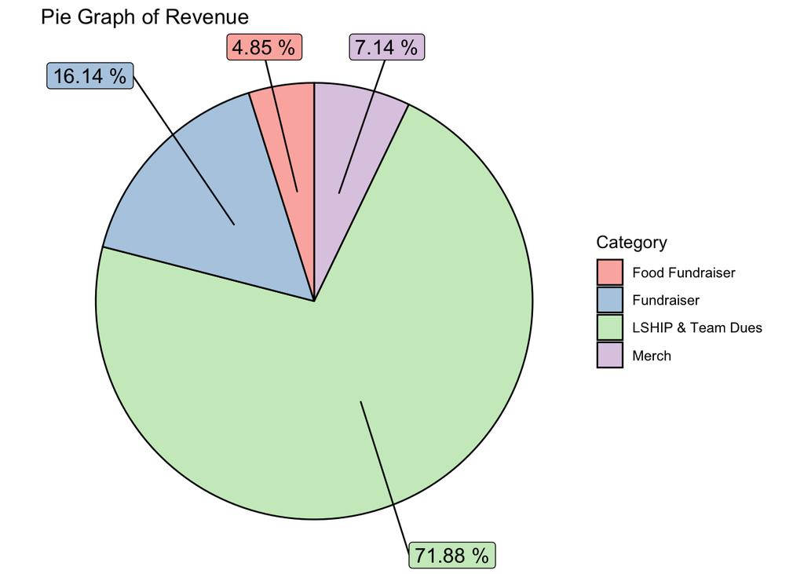

```
## [1] 16964.79
```

In 2022, Foundations Choregraphy generated `$16,964.79` from fundraising, lship and team dues, and Merch. Merch sales don’t seem to be doing so well in comparing the ratio to the others such as team dues and fundraising. With this in mind, it’s best in my opinion to hold back on ordering merch in bulk. The bulk of our money comes from lship and team dues and fundraising. The exact components in lship and team dues includes CAMP FC fees, team dues, and retreat dues. For the next year, we can try to increase the ratio of fundraising to lship and team dues. A suggestion I have is to buy around 120 roses on top of the pre-ordered roses as we tend to sell out fast, then steadily increase the quantity by 60 each quarter. Another way to also increase fundraising could be having fundraisers dealing with “partying”. Before, the bulk of the money came from clubbing at Arena, perhaps a funradger or a dance party may help replicate that scene. For now, let’s look at our losses from the quarter.

## Section 2 - Loss from 2021-2022

Now let’s look at the losses in each category and see what we can do to minimize the losses for the future. This is a table of all the losses that has occurred from 2021-2022 from paying reimbursements and paying for merch.

**Click for Table**

|  | ID | Date | Type | Status | Description | From | To | Amount | Category |
| --- | --- | --- | --- | --- | --- | --- | --- | --- | --- |
| 1 | 3375222434302001733 | 2021-10-01T22:04:28 | Payment | Complete | Reimbursement | Foundations Choreography | Leeba Farooqi | 71.16 | Payments |
| 39 | 3377396582440763728 | 2021-10-04T22:04:07 | Payment | Complete | Reimbursement | Foundations Choreography | Aaron Chien | 4.70 | Payments |
| 40 | 3377396897818870475 | 2021-10-04T22:04:44 | Payment | Complete | LSHIP Jackets | Foundations Choreography | Leeba Farooqi | 408.62 | LSHIP & Team Dues |
| 41 | 3382552809437135072 | 2021-10-12T00:48:37 | Payment | Complete | Reimbursement | Foundations Choreography | Leeba Farooqi | 320.00 | Payments |
| 61 | 3390282507143348286 | 2021-10-22T16:46:09 | Payment | Complete | Reimbursement | Foundations Choreography | celine nguyen | 141.36 | Payments |
| 62 | 3390283210318414671 | 2021-10-22T16:47:32 | Payment | Complete | Reimbursement | Foundations Choreography | celine nguyen | 12.87 | Payments |
| 63 | 3390284049170825920 | 2021-10-22T16:49:12 | Payment | Complete | Retreat Dues | Foundations Choreography | celine nguyen | 92.46 | LSHIP & Team Dues |
| 64 | 3390594625856078360 | 2021-10-23T03:06:16 | Payment | Complete | Retreat Dues | Foundations Choreography | Sharon Wong | 45.72 | LSHIP & Team Dues |
| 67 | 3407775251784794347 | 2021-11-15T20:01:06 | Payment | Complete | Down Bad Dues | Foundations Choreography | Elaine Yan | 940.50 | LSHIP & Team Dues |
| 101 | 3416595962653573907 | 2021-11-28T00:06:17 | Charge | Complete | Sparktrendz Payment | Ambrose So | Foundations Choreography | 3062.50 | Payments |
| 135 | 3428471960367177764 | 2021-12-14T09:21:46 | Payment | Complete | Reimbursement | Foundations Choreography | celine nguyen | 20.79 | Payments |
| 136 | 3428473157170065249 | 2021-12-14T09:24:09 | Payment | Complete | Reimbursement | Foundations Choreography | celine nguyen | 54.74 | Payments |
| 137 | 3428851171100274648 | 2021-12-14T21:55:12 | Payment | Complete | Rose Fundraiser | Foundations Choreography | celine nguyen | 105.10 | Fundraiser |
| 138 | 3428852701182534886 | 2021-12-14T21:58:14 | Payment | Complete | Reimbursement | Foundations Choreography | celine nguyen | 15.00 | Payments |
| 139 | 3428877850396668695 | 2021-12-14T22:48:12 | Payment | Complete | Reimbursement | Foundations Choreography | celine nguyen | 18.48 | Payments |
| 140 | 3428879517355625294 | 2021-12-14T22:51:31 | Payment | Complete | Reimbursement | Foundations Choreography | celine nguyen | 27.36 | Payments |
| 141 | 3431279446589597183 | 2021-12-18T06:19:45 | Payment | Complete | Reimbursement | Foundations Choreography | Sharon Wong | 75.46 | Payments |
| 143 | 3459390598058339325 | 2022-01-26T01:11:35 | Payment | Complete | Reimbursement | Foundations Choreography | celine nguyen | 78.82 | Payments |
| 255 | 3477447279958982982 | 2022-02-19T23:06:59 | Payment | Complete | Wintensive Choregrapher | Foundations Choreography | Matthew Sabino | 300.00 | Wintensive Payment |
| 273 | 3477541487197857771 | 2022-02-20T02:14:10 | Payment | Complete | Wintensive Choregrapher | Foundations Choreography | Anthony Vibal | 306.00 | Wintensive Payment |
| 290 | 3478159674733632130 | 2022-02-20T22:42:23 | Payment | Complete | Wintensive Merch | Foundations Choreography | Anthony Pastizzo | 20.00 | Merch |
| 349 | 3481365261591981353 | 2022-02-25T08:51:19 | Payment | Complete | Pie Fundraiser | Foundations Choreography | Ashley Zhu | 2.00 | Fundraiser |
| 357 | 3482026936041906799 | 2022-02-26T06:45:57 | Payment | Complete | Teaspoon Fundraiser | Foundations Choreography | Luke Kyaw | 0.05 | Food Fundraiser |
| 358 | 3482027224618119856 | 2022-02-26T06:46:31 | Payment | Complete | Teaspoon Fundraiser | Foundations Choreography | Regina Wang | 0.05 | Food Fundraiser |
| 359 | 3483203934138415263 | 2022-02-27T21:44:26 | Payment | Complete | Pie Fundraiser | Foundations Choreography | Leeba Farooqi | 6.55 | Fundraiser |
| 360 | 3483252307072410592 | 2022-02-27T23:20:32 | Payment | Complete | Valentines Gram Fundraiser | Foundations Choreography | Leeba Farooqi | 89.09 | Fundraiser |
| 361 | 3483254278294836398 | 2022-02-27T23:24:27 | Payment | Complete | Banquet Fees | Foundations Choreography | Leeba Farooqi | 21.90 | Payments |
| 378 | 3488607663172181788 | 2022-03-07T08:40:41 | Charge | Complete | BOFA Dues | Brandon Samoranos | Foundations Choreography | 12.00 | LSHIP & Team Dues |
| 418 | 3493399628128636730 | 2022-03-13T23:21:27 | Charge | Complete | Banquet Fees | Brandon Samoranos | Foundations Choreography | 18.00 | Payments |
| 419 | 3493414278538536645 | 2022-03-13T23:50:34 | Payment | Complete | Retreat Dues | Foundations Choreography | Myles Chang | 838.77 | LSHIP & Team Dues |

[output cut: 52 more lines]

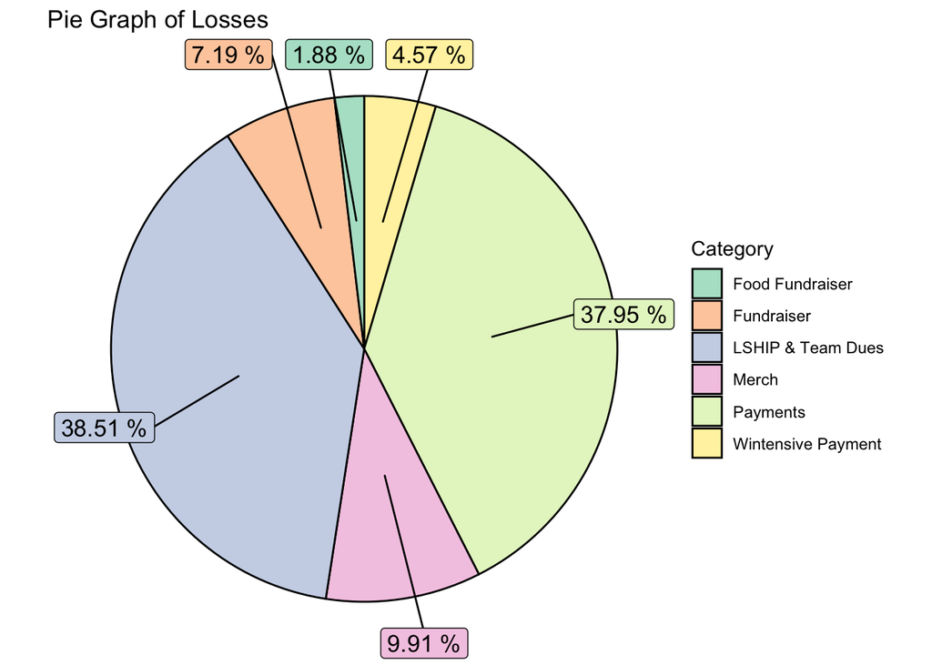

```
## [1] 13266.58
```

Oh no! We have spent `$13,266.58` in total payments and fees! Looking at the pie chart, most of it has been spent on the category of payments and LSHIP & Team Dues. Payments includes reimbursements that didn’t fit into any other category, banquet fees, and one large payment for merch. Some of these reimbursements were for showcase, auds, and pre-auds. Wintensive Payment was for Anthony Vibal and Matthew Sabino, wintensive choregraphers. Fundraisers and Food Fundraiser payments are typically reimbursements to pay for the materials and food needed to sell and merch includes buying the clothes such as wintensive. LSHIP and team dues main payments were paying for the retreat, paying for CAMP FC gear, the `$30` stipend for each team, and Sparktrendz shirts for teams.

Looking at the category of payments even more closely, we can observe which description goes to which data and take notes.

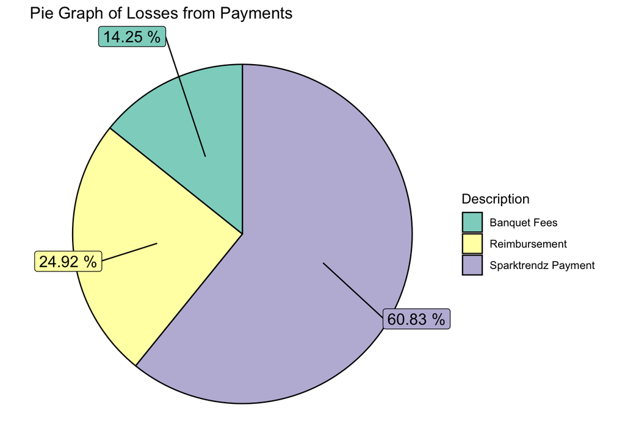

**Click for Table**

|  | ID | Date | Type | Status | Description | From | To | Amount | Category |
| --- | --- | --- | --- | --- | --- | --- | --- | --- | --- |
| 1 | 3375222434302001733 | 2021-10-01T22:04:28 | Payment | Complete | Reimbursement | Foundations Choreography | Leeba Farooqi | 71.16 | Payments |
| 39 | 3377396582440763728 | 2021-10-04T22:04:07 | Payment | Complete | Reimbursement | Foundations Choreography | Aaron Chien | 4.70 | Payments |
| 41 | 3382552809437135072 | 2021-10-12T00:48:37 | Payment | Complete | Reimbursement | Foundations Choreography | Leeba Farooqi | 320.00 | Payments |
| 61 | 3390282507143348286 | 2021-10-22T16:46:09 | Payment | Complete | Reimbursement | Foundations Choreography | celine nguyen | 141.36 | Payments |
| 62 | 3390283210318414671 | 2021-10-22T16:47:32 | Payment | Complete | Reimbursement | Foundations Choreography | celine nguyen | 12.87 | Payments |
| 101 | 3416595962653573907 | 2021-11-28T00:06:17 | Charge | Complete | Sparktrendz Payment | Ambrose So | Foundations Choreography | 3062.50 | Payments |
| 135 | 3428471960367177764 | 2021-12-14T09:21:46 | Payment | Complete | Reimbursement | Foundations Choreography | celine nguyen | 20.79 | Payments |
| 136 | 3428473157170065249 | 2021-12-14T09:24:09 | Payment | Complete | Reimbursement | Foundations Choreography | celine nguyen | 54.74 | Payments |
| 138 | 3428852701182534886 | 2021-12-14T21:58:14 | Payment | Complete | Reimbursement | Foundations Choreography | celine nguyen | 15.00 | Payments |
| 139 | 3428877850396668695 | 2021-12-14T22:48:12 | Payment | Complete | Reimbursement | Foundations Choreography | celine nguyen | 18.48 | Payments |
| 140 | 3428879517355625294 | 2021-12-14T22:51:31 | Payment | Complete | Reimbursement | Foundations Choreography | celine nguyen | 27.36 | Payments |
| 141 | 3431279446589597183 | 2021-12-18T06:19:45 | Payment | Complete | Reimbursement | Foundations Choreography | Sharon Wong | 75.46 | Payments |
| 143 | 3459390598058339325 | 2022-01-26T01:11:35 | Payment | Complete | Reimbursement | Foundations Choreography | celine nguyen | 78.82 | Payments |
| 361 | 3483254278294836398 | 2022-02-27T23:24:27 | Payment | Complete | Banquet Fees | Foundations Choreography | Leeba Farooqi | 21.90 | Payments |
| 418 | 3493399628128636730 | 2022-03-13T23:21:27 | Charge | Complete | Banquet Fees | Brandon Samoranos | Foundations Choreography | 18.00 | Payments |
| 420 | 3496197886907080745 | 2022-03-17T20:01:06 | Payment | Complete | Reimbursement | Foundations Choreography | Michelle Le | 15.00 | Payments |
| 421 | 3507366881824375028 | 2022-04-02T05:51:54 | Payment | Complete | Reimbursement | Foundations Choreography | Joshua Baysa | 43.79 | Payments |
| 509 | 3517257854242617433 | 2022-04-15T21:23:29 | Payment | Complete | Reimbursement | Foundations Choreography | Myles Chang | 205.84 | Payments |
| 515 | 3517494395833864691 | 2022-04-16T05:13:27 | Payment | Complete | Reimbursement | Foundations Choreography | celine nguyen | 68.11 | Payments |
| 532 | 3526072093216662764 | 2022-04-28T01:15:49 | Payment | Complete | Reimbursement | Foundations Choreography | Vincent Leong | 51.45 | Payments |
| 818 | 3556561307191891976 | 2022-06-09T02:52:26 | Payment | Complete | Banquet Fees | Foundations Choreography | Myles Chang | 367.92 | Payments |
| 820 | 3559529487745676492 | 2022-06-13T05:09:41 | Payment | Complete | Banquet Fees | Foundations Choreography | Brenda Tran | 69.02 | Payments |
| 821 | 3559532026926531331 | 2022-06-13T05:14:44 | Payment | Complete | Banquet Fees | Foundations Choreography | celine nguyen | 6.57 | Payments |
| 822 | 3559534192110306278 | 2022-06-13T05:19:02 | Payment | Complete | Banquet Fees | Foundations Choreography | celine nguyen | 39.39 | Payments |
| 823 | 3559536448897198270 | 2022-06-13T05:23:31 | Payment | Complete | Banquet Fees | Foundations Choreography | celine nguyen | 5.93 | Payments |
| 824 | 3559537919302716973 | 2022-06-13T05:26:26 | Payment | Complete | Banquet Fees | Foundations Choreography | celine nguyen | 18.60 | Payments |
| 825 | 3559541632813944491 | 2022-06-13T05:33:49 | Payment | Complete | Reimbursement | Foundations Choreography | celine nguyen | 29.55 | Payments |
| 827 | 3559934239105088438 | 2022-06-13T18:33:51 | Payment | Complete | Banquet Fees | Foundations Choreography | Ixtzaly Salas | 170.32 | Payments |

Examining the data even more, the one payment to Sparktrendz for merch is what covers most of the payment area! Since merch sales do not make up the bulk of what we earn, I suggest for the fall quarter to not order any merch unless it is for teams (team merch is included in the LSHIP and team dues category, and the team dues description). If we are in short supply, examine how much merch sales is then proceed to buy more, I suggest buying one box as totes are the more popular merch items. We paid around `$1254` in reimbursements this year, which includes all the showcase reimbursements and pre-auds/auds events. I suspect that these will be constants but we can deduct around `$200` if we choose to not do LSHIP gifts (data from Ixtzaly) and if we do not lose the table that Josh brought.

If you would like, you can observe the old data of where all Foundations Choreography payments came from.

**Click for Table**

|  | ID | Date | Type | Status | Description | From | To | Amount |
| --- | --- | --- | --- | --- | --- | --- | --- | --- |
| 1 | 3375222434302001733 | 2021-10-01T22:04:28 | Payment | Complete | staples flyers 100x | Foundations Choreography | Leeba Farooqi | - $71.16 |
| 39 | 3377396582440763728 | 2021-10-04T22:04:07 | Payment | Complete | for ziplocks reimbursement | Foundations Choreography | Aaron Chien | - $4.70 |
| 40 | 3377396897818870475 | 2021-10-04T22:04:44 | Payment | Complete | Fore lship jacket reimbursement | Foundations Choreography | Leeba Farooqi | - $408.62 |
| 41 | 3382552809437135072 | 2021-10-12T00:48:37 | Payment | Complete | Reimbursement for embroidery | Foundations Choreography | Leeba Farooqi | - $320.00 |
| 61 | 3390282507143348286 | 2021-10-22T16:46:09 | Payment | Complete | Reimbursement for speakers | Foundations Choreography | celine nguyen | - $141.36 |
| 62 | 3390283210318414671 | 2021-10-22T16:47:32 | Payment | Complete | payment of blue tape | Foundations Choreography | celine nguyen | - $12.87 |
| 63 | 3390284049170825920 | 2021-10-22T16:49:12 | Payment | Complete | payment for retreat groceries | Foundations Choreography | celine nguyen | - $92.46 |
| 64 | 3390594625856078360 | 2021-10-23T03:06:16 | Payment | Complete | reimbursement for alcohol | Foundations Choreography | Sharon Wong | - $45.72 |
| 67 | 3407775251784794347 | 2021-11-15T20:01:06 | Payment | Complete | To pay for reimbursement of tshirts | Foundations Choreography | Elaine Yan | - $940.50 |
| 101 | 3416595962653573907 | 2021-11-28T00:06:17 | Charge | Complete | Gift 🎁 | Ambrose So | Foundations Choreography | - $3,062.50 |
| 135 | 3428471960367177764 | 2021-12-14T09:21:46 | Payment | Complete | reimbursement for wristbands | Foundations Choreography | celine nguyen | - $20.79 |
| 136 | 3428473157170065249 | 2021-12-14T09:24:09 | Payment | Complete | reimbursement for walkie talkies | Foundations Choreography | celine nguyen | - $54.74 |
| 137 | 3428851171100274648 | 2021-12-14T21:55:12 | Payment | Complete | Roses reimbursement | Foundations Choreography | celine nguyen | - $105.10 |
| 138 | 3428852701182534886 | 2021-12-14T21:58:14 | Payment | Complete | target gift card reimbursement | Foundations Choreography | celine nguyen | - $15.00 |
| 139 | 3428877850396668695 | 2021-12-14T22:48:12 | Payment | Complete | batteries reimbursement | Foundations Choreography | celine nguyen | - $18.48 |
| 140 | 3428879517355625294 | 2021-12-14T22:51:31 | Payment | Complete | tripod reimbursement | Foundations Choreography | celine nguyen | - $27.36 |
| 141 | 3431279446589597183 | 2021-12-18T06:19:45 | Payment | Complete | pizza reimbursement | Foundations Choreography | Sharon Wong | - $75.46 |
| 143 | 3459390598058339325 | 2022-01-26T01:11:35 | Payment | Complete | Voice Amplifier Reimbursement | Foundations Choreography | celine nguyen | - $78.82 |
| 255 | 3477447279958982982 | 2022-02-19T23:06:59 | Payment | Complete | Wintensive | Foundations Choreography | Matthew Sabino | - $300.00 |
| 273 | 3477541487197857771 | 2022-02-20T02:14:10 | Payment | Complete | wintensive + parking | Foundations Choreography | Anthony Vibal | - $306.00 |
| 290 | 3478159674733632130 | 2022-02-20T22:42:23 | Payment | Complete | Wintensive shirt refund | Foundations Choreography | Anthony Pastizzo | - $20.00 |
| 349 | 3481365261591981353 | 2022-02-25T08:51:19 | Payment | Complete | reimbursement pie | Foundations Choreography | Ashley Zhu | - $2.00 |
| 357 | 3482026936041906799 | 2022-02-26T06:45:57 | Payment | Complete | boba: $6.45 but paid $6.50 | Foundations Choreography | Luke Kyaw | - $0.05 |
| 358 | 3482027224618119856 | 2022-02-26T06:46:31 | Payment | Complete | boba: $6.45 but paid $6.50 | Foundations Choreography | Regina Wang | - $0.05 |
| 359 | 3483203934138415263 | 2022-02-27T21:44:26 | Payment | Complete | Reimbursement for plates for pie fundraiser | Foundations Choreography | Leeba Farooqi | - $6.55 |
| 360 | 3483252307072410592 | 2022-02-27T23:20:32 | Payment | Complete | reimbursement of Leeba’s payment of valentine’s gram fundraiser: bears, heart tags, notes | Foundations Choreography | Leeba Farooqi | - $89.09 |
| 361 | 3483254278294836398 | 2022-02-27T23:24:27 | Payment | Complete | Reimbursement of bags | Foundations Choreography | Leeba Farooqi | - $21.90 |
| 378 | 3488607663172181788 | 2022-03-07T08:40:41 | Charge | Complete | For BOFA gear material reimbursement, using the $30 stipend | Brandon Samoranos | Foundations Choreography | - $12.00 |
| 418 | 3493399628128636730 | 2022-03-13T23:21:27 | Charge | Complete | For BOFA banquet food and paper printing for LOVE NOTES, remaining balance of stipend is $0 | Brandon Samoranos | Foundations Choreography | - $18.00 |
| 419 | 3493414278538536645 | 2022-03-13T23:50:34 | Payment | Complete | to record reimbursement request payment: Myles for airbnb winter retreat | Foundations Choreography | Myles Chang | - $838.77 |

[output cut: 55 more lines]

## Section 3 - Financial Health

In this section, we can use financial pratices used in real life to evaluate the financial health of Foundations.

### Section 3.1 - Revenue Growth

Revenue Growth is the percent change in revenue from each period. In our case, we would use each quarter as 1 period and calculate the revenue growth from one period to the next.

| Period | Revenue |
| --- | --- |
| Fall | 2038.00 |
| Winter | 4930.65 |
| Spring | 9996.14 |

```
## Revenue Growth from Fall to Winter
##                         "141.94 %"
```

Great news! The revenue growth from fall quarter to winter quarter was `141.94%`! That is a really large growth and is most likely contributed to having three teams in the winter quarter.

```
## Revenue Growth from Winter to Spring
##                           "102.73 %"
```

The revenue growth from winter to spring was `102.73%`. This is still really good and amazing. Overall, the revenue growth for each period is very healthy.

### Section 3.2 - Revenue Growth Per Team

As Foundations Choregrapher grew over the year, so did the size of our teams. We can examine the teams more closely and see what was the revenue growth per team.

```
## Revenue Growth per Team from Fall to Winter
##                                   "64.41 %"
```

Hurray! Even if we account for more teams in the winter quarter, we still saw a `64.41%` in revenue growth!

```
## Revenue Growth per Team from Winter to Spring
##                                     "78.45 %"
```

Even better! We had a `78.45%` revenue growth from winter to spring! This is all wonderful news and can be attributed to the fact that as rose fundraisers are our most popular fundraiser during the quarter, the more teams there are, the more fundraising will happen!

### Section 3.3 - Profit Margin

```
## Net Profit Margin
##         "21.80 %"
```

The net profit margin is `21.80%`! This is a very high net profit margin as it means that `21.80%` of our revenue per unit becomes profit! From observing the revenue growth and the net profit margin, Foundations Choregraphy is at a healthy financial standing.

## Section 4 - Regression Lines

Speaking on the topic of teams and fundraising, we can try to see if we can graph a relationship between the number of teams and rose sales and pie fundraisers. We first create a data frame of the number of teams and the funding from rose sales and pie fundraisers.

| Number of Teams | Rose Sales | Pie Fundraiser |
| --- | --- | --- |
| 1 | 291.0 | 45.00 |
| 3 | 383.0 | 132.00 |
| 5 | 1028.5 | 426.01 |

Then we graph!

### Section 4.1 - Regression on Roses

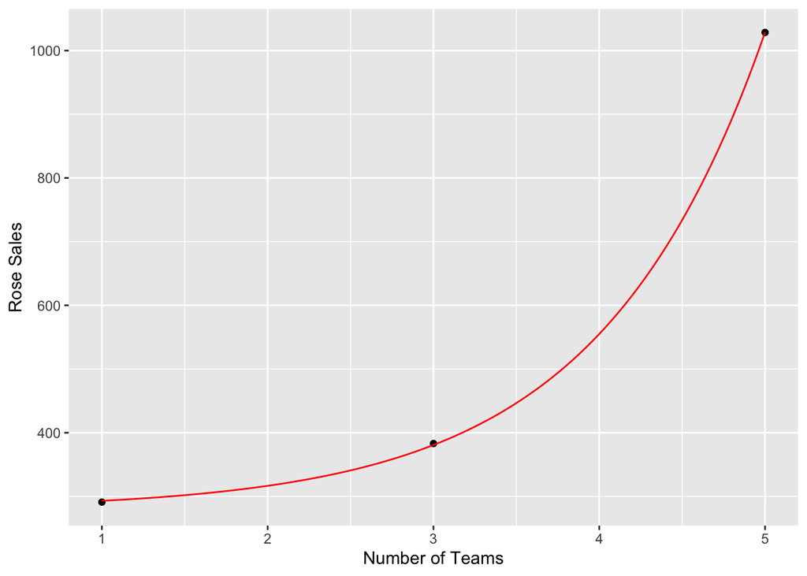

```
##
## Call:
## lm(formula = (RP_teams$`Rose Sales`) ~ exp(RP_teams$`Number of Teams`))
##
## Residuals:
##       1       2       3
## -2.0115  2.2837 -0.2722
##
## Coefficients:
##                                  Estimate Std. Error t value Pr(>|t|)
## (Intercept)                     279.28412    2.34790     119  0.00535 **
## exp(RP_teams$`Number of Teams`)   5.05001    0.02715     186  0.00342 **
## ---
## Signif. codes:  0 '***' 0.001 '**' 0.01 '*' 0.05 '.' 0.1 ' ' 1
##
## Residual standard error: 3.055 on 1 degrees of freedom
## Multiple R-squared:      1,  Adjusted R-squared:  0.9999
## F-statistic: 3.46e+04 on 1 and 1 DF,  p-value: 0.003422
```

Here, the red line is the relationship between the number of teams and the amount of rose sales we get! The model for this is:

`y = 279.28412 + 5.05001 * exp(x)`

| 1 rose | 2 roses | 6 roses | 12 roses |
| --- | --- | --- | --- |
| `$3.00` | `$5.00` | `$12.00` | `$16.00` |

### Section 4.2 - Regression on Pies

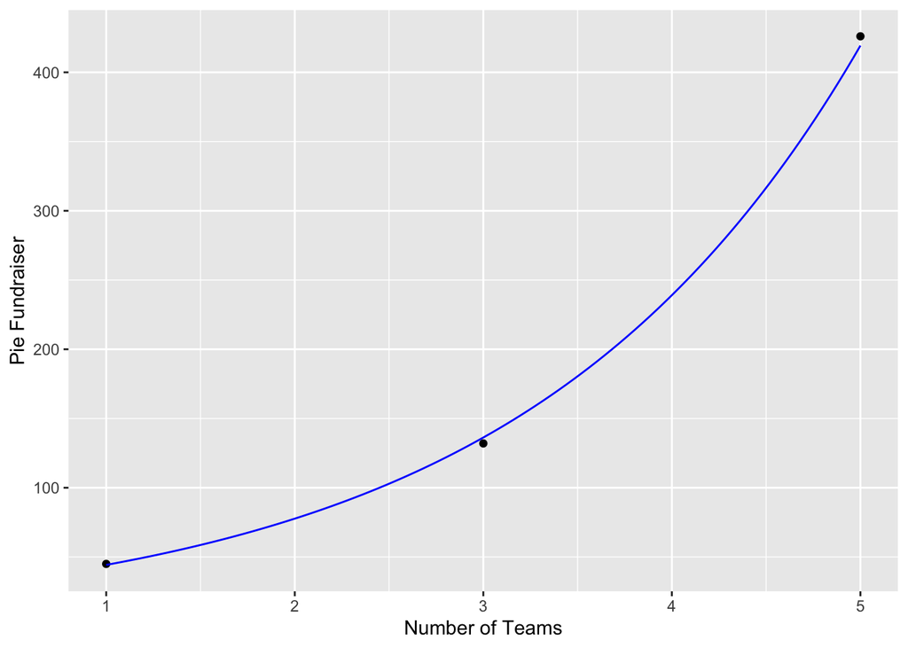

```
##
## Call:
## lm(formula = log(RP_teams$`Pie Fundraiser`) ~ RP_teams$`Number of Teams`)
##
## Residuals:
##        1        2        3
##  0.01592 -0.03184  0.01592
##
## Coefficients:
##                            Estimate Std. Error t value Pr(>|t|)
## (Intercept)                 3.22879    0.04709   68.56  0.00928 **
## RP_teams$`Number of Teams`  0.56195    0.01379   40.76  0.01562 *
## ---
## Signif. codes:  0 '***' 0.001 '**' 0.01 '*' 0.05 '.' 0.1 ' ' 1
##
## Residual standard error: 0.039 on 1 degrees of freedom
## Multiple R-squared:  0.9994, Adjusted R-squared:  0.9988
## F-statistic:  1661 on 1 and 1 DF,  p-value: 0.01562
```

The model for the number of teams and pie fundraiser is:

`ln(y) = 3.22879 + 0.56195x`

| Pie | Flour | Egg |
| --- | --- | --- |
| `$2.00` | `$2.00` | `$3.00` |

## Section 5 - Final Words

So how can future admin use this data after seeing how 2021-2022 performed?

1. You can utilize this report to examine how much money each team can bring in looking at the sum of the `Team Dues` description.
2. Find out how much cost can be cutted down when planning banquet and retreat by comparing prices.
3. Use the previous fundraisers data to see how much money it got us and use that as an estimate when budgeting.
4. You can use the models to predict sales in rose and pie fundraisers.